# Análisis de las variables psicosociales relacionadas al redimiento académico: Prueba SIMCE cuartos básicos

# Resultados

### Análisis descriptivo

Para comenzar, visualizaremos en la siguiente tabla, un resumen de la muestra en relación al puntaje obtenido en cada prueba.

| -- | Puntajes Prueba Lectura | Puntajes Prueba Matemática |
| --- | --- | --- |
| Mínimo | 149 | 129 |
| 1er Cuartil | 245 | 231 |
| Mediana | 262 | 249 |
| 3er Cuartil | 280 | 269 |
| Máximo | 396 | 376 |
| Promedio | 262.2 | 250.3 |

Estos resultados se pueden visualizar también a partir de un gráfico de cajas y bigotes, en donde las lineas horizontales inferiores y superiores muestran los valores minimos y maximos respectivamente, y las lineas horizontales de la caja coloreada representan el primer, segundo(mediana) y tercer cuartil. Además, especificamente en este caso, se incorporó el valor de la media con una equis roja en el punto correspondiente en el gráfico.

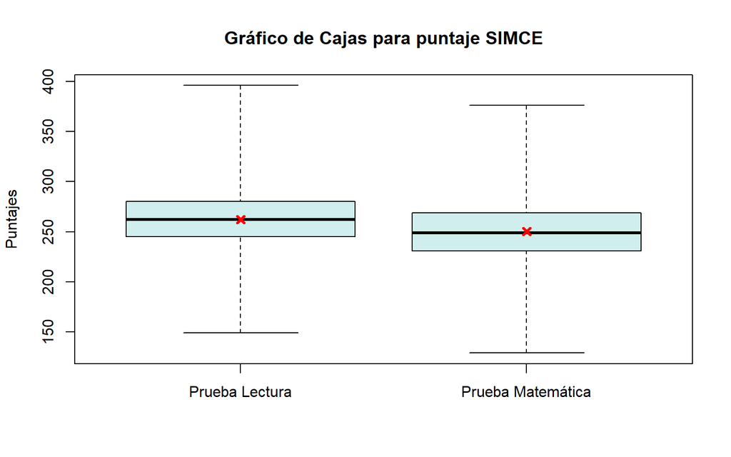

Uno de los ejes principales de la presente investigación fue encontrar relaciones entre las variables psicosociales y los puntajes obtenidos por los estudiantes, para ello se separaron los datos de cada nivel de la variable categórica psicosocial y se calcularon los promedios de puntajes para cada prueba.

En las siguientes tablas se definirá una varibale categórica de referencia para realizar análisis de promedios para cada nivel de la variable.

#### Análisis de promedios Nivel Socioeconómico

La variable *"Nivel socioeconómico"* tiene como niveles las categorías: Bajo, Medio-bajo, Medio, Medio-alto y Alto. Se calculará el promedio de la prueba de lectura y de matemática para cada uno de estos niveles.

Tabla 1

| Nivel Socioeconómico | Promedios Prueba Lectura | Promedios Prueba Matemática |
| --- | --- | --- |
| Bajo | 253.25 | 236.15 |
| Medio-Bajo | 259.74 | 247.47 |
| Medio | 265.08 | 256.89 |
| Medio-alto | 280.88 | 272.90 |
| Alto | 296.43 | 290.87 |

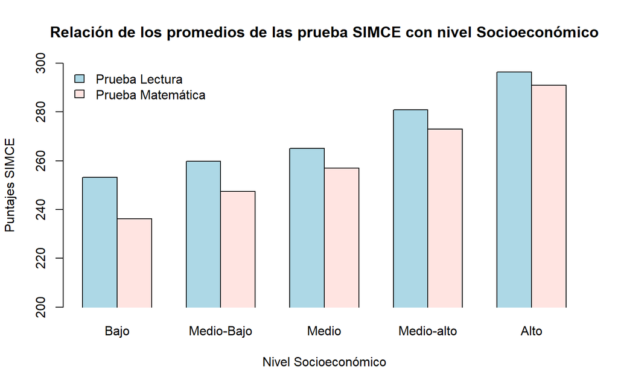

Lo que podemos apreciar en la *Tabla 1* y la gráfica a siguiente que lo representa, es que los puntajes promedio más bajos se encuentran en el nivel socioeconómico Bajo, y a medida que el nivel socioeconómico sube también lo hacen los puntajes. Esto permite algunas interpretaciones obvias como que a mayor nivel socioeconomico se recibe una educación de mejor calidad, o desde otra mirada, que a mayor nivel socioeconomico mejores condiciones permiten que al rendir la prueba se obtengan mejores resultados. Sería interesante conocer qué condiciones son las que permiten este mejor desempeño.

#### Análisis de promedios Convivencia Escolar

Al realizar el mismo analisis anterior a la variable ConvivenciaEscolar, obtenemos lo siguiente,

Tabla 2

| Puntaje de Convivencia Escolar | Promedios Prueba Lectura | Promedios Prueba Matemática |
| --- | --- | --- |
| (30,47.5] | 231.33 | 212.33 |
| (47.5,65] | 232.90 | 223.06 |
| (65,82.5] | 261.84 | 250.42 |
| (82.5,100] | 279.56 | 262.52 |

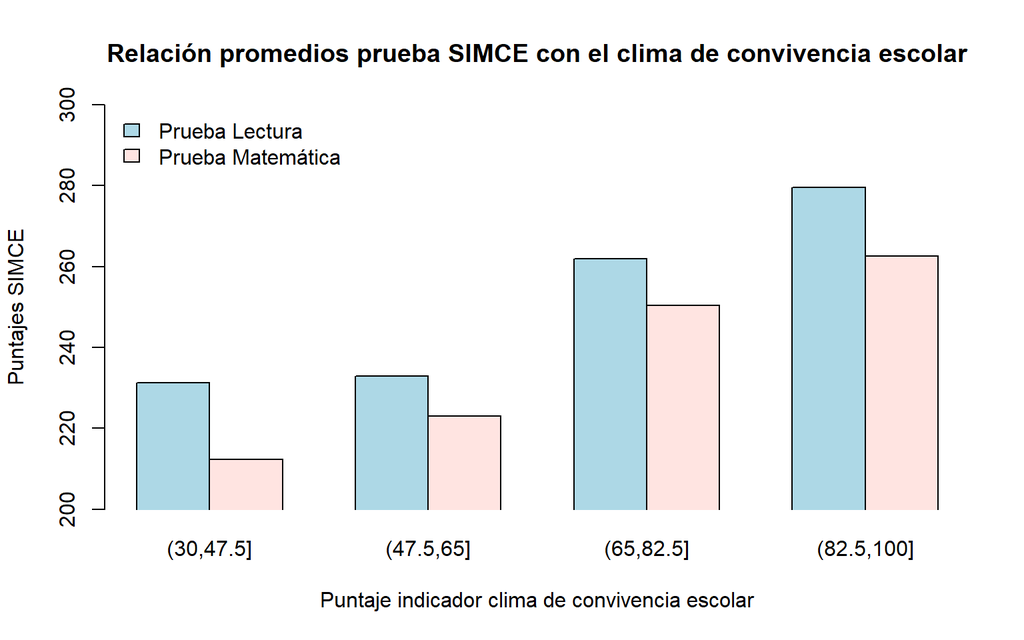

Al observar la *Tabla 2* podemos darnos cuenta que los resultados son muy similares a la variable estudiada en el punto anterior (Nivel socioeconómico), por lo que también se puede inferir que el Clima de convivencia escolar por sí solo afecta positivamente en la rendición de la prueba y los resultados obtenidos.

#### Análisis de promedios para criterio de Hábitos Saludables

Se realiza el mismo análisis anterior, que se ve representado en la tabla y grafica a continuación:

Tabla 3

| Puntaje Hábitos saludables en colegio | Promedios Prueba Lectura | Promedios Prueba Matemática |
| --- | --- | --- |
| (30,47.5] | 224.49 | 210.47 |
| (47.5,65] | 245.48 | 234.81 |
| (65,82.5] | 266.04 | 254.35 |
| (82.5,100] | 278.31 | 256.33 |

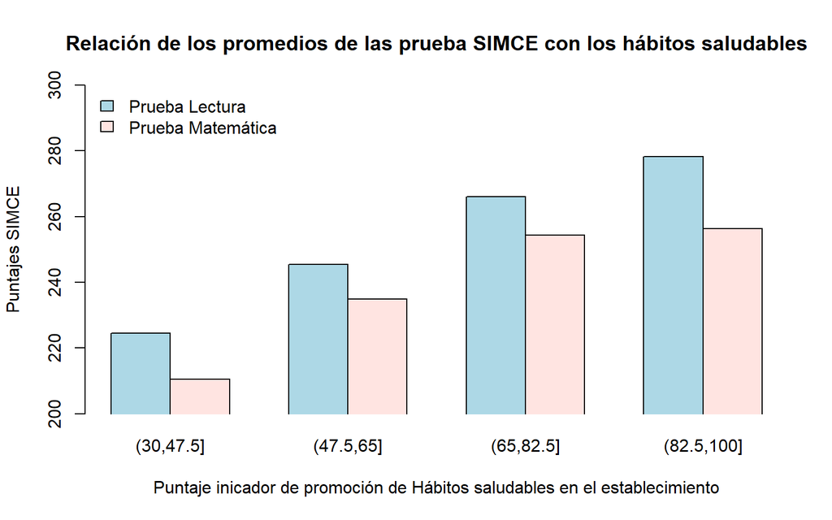

Es posible notar que los valores de la *Tabla 3*, también se comportan de una manera similar a lo observado en los análisis anteriores, es decir, aumentando el nivel de promoción de hábitos saludables en los establecimientos, también sube el puntaje promedio obtenido por los estudiantes, pero no podemos aserverar de manera concreta esta relación pues para la prueba de matemática, en las dos categorías más altas, los puntajes promedios son muy similares, lo que nos podría indicar que los datos en todo ese intervalo, se comportan de manera muy similar, o bien de manera muy dispersa. Lo mejor en este caso es hacer otro tipo de análisis, por ejemplo, un análisis de correlación para ver como se comportan los datos de forma más concluyente.

#### Análisis de promedios para criterio de Autoestima de los estudiantes

Se realizan los mismos análisis anteriores, que se ven representado en la tabla y grafica a continuación:

Tabla 4

| Puntaje promedio del Autoestima del estudiante | Promedios Prueba Lectura | Promedios Prueba Matemática |
| --- | --- | --- |
| (30,47.5] | 222.86 | 201.34 |
| (47.5,65] | 242.36 | 225.16 |
| (65,82.5] | 262.75 | 251.33 |
| (82.5,100] | 272.49 | 255.75 |

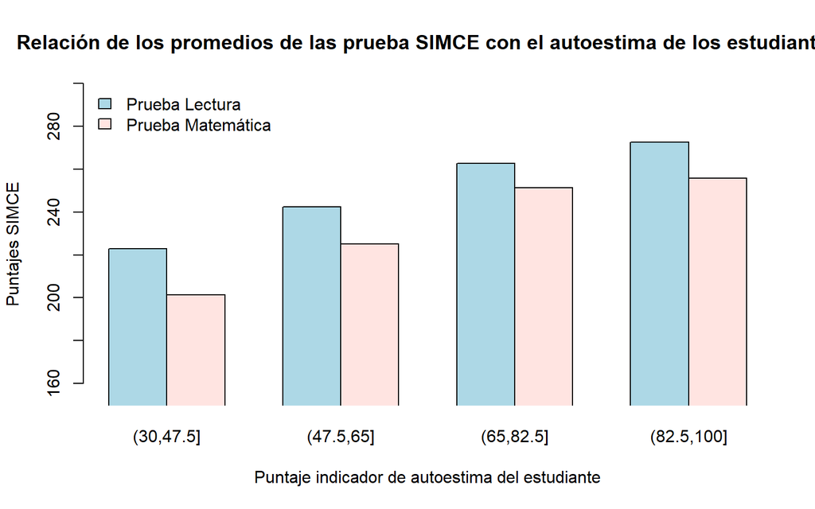

Es posible notar con los datos de la *Tabla 4* que a medida que aumenta el promedio de autoestima de los estudiantes en los establecimientos, obtienen mejores puntajes promedios en la prueba simce.

#### Análisis de promedios para criterio de Formación cuidadana en los establecimientos

Se realizan los mismos análisis anteriores, que se ven representado en la tabla y grafica a continuación:

Tabla 5

| Puntaje Promedio formación ciudadana | Promedios Prueba Lectura | Promedios Prueba Matemática |
| --- | --- | --- |
| (30,47.5] | 246.00 | 237.81 |
| (47.5,65] | 240.12 | 225.03 |
| (65,82.5] | 260.98 | 249.96 |
| (82.5,100] | 269.34 | 254.72 |

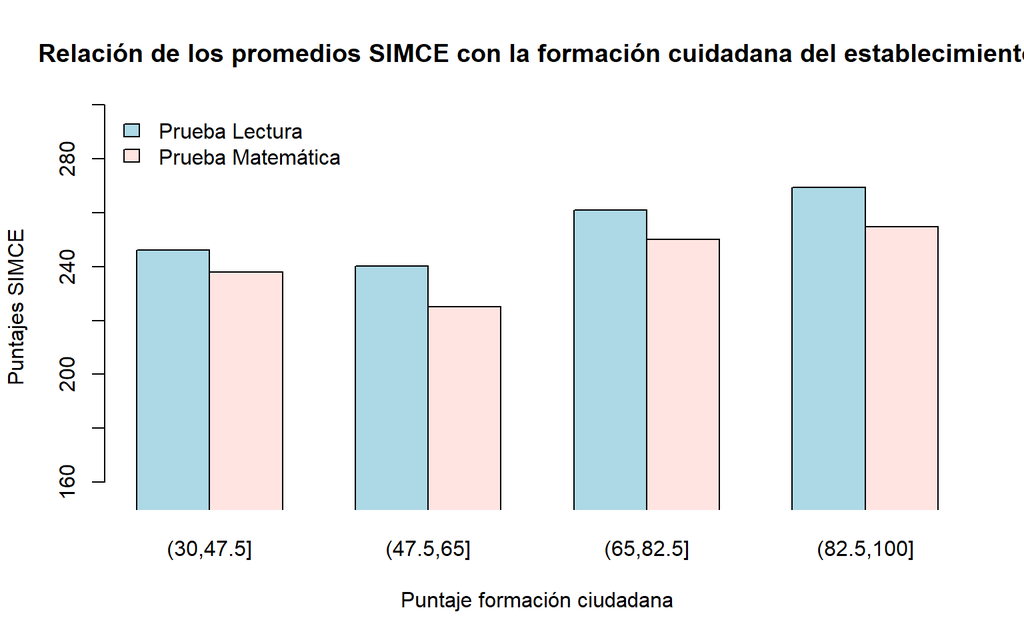

### Análisis de Regresión

Se comenzó el análisis creando dos modelos de regresión lineal con variables respuestas *PtjeLectura* y *PtjeMatematica*. Para cada uno de ellos se utilizaron como variables explicativas las variables *Autoestima*, *Convivencia*, *HabitosSaludables* y *FormacionCiudadana*.

El modelo para la prueba de lectura obtuvo un $R^2$ de 0.2636, lo cual es bastante bajo, considerando que el ideal de un modelo es acercar su $R^2$ lo más posible al valor de 1. En cuanto al modelo para la prueba de matemática se obtuvo un $R^2$ de 0.1816, un valor bastante bajo tambien.

El propósito en las siguiente lineas será mejorar el ajuste de nuestro modelo, chequeando algunos problemas de los datos, que podrían estar perjudicando la regresión.

#### Multicolinealidad

La multicolinealidad es un problema existente en algunas bases de datos, en donde ciertas variables se encuentran correlacionadas con las demás, causando de esta forma redundancia en el modelo. Para verificar que no exista esta dependencia entre variables se utilizó el índice VIF que nos indica que si existe o no multicolinealidad entre las variables, obteniendo lo siguiente

Tabla 6

| Variables explicativas | VIF modelo lectura | VIF modelo matematica |
| --- | --- | --- |
| Autoestima | 1.8428 | 1.8428 |
| Convivencia | 2.0197 | 2.0197 |
| HabitosSaludables | 2.1616 | 2.1616 |
| FormacionCiudadana | 2.9224 | 2.9224 |

como podemos notar en la *Tabla 6* todos los valores VIF son menores a 10, por lo que no estaríamos en presencia de multicolinealidad para ninguno de los modelos.

#### Independencia

Uno de los tres supuestos que debe cumplir un modelo de regresión lineal es la independencia. Para verificar este supuesto se realizó el test de Durbin Watson que nos dió como resultado la no existencia de independencia, y se puede visualizar el mismo resultado en la grafica a continuacion.

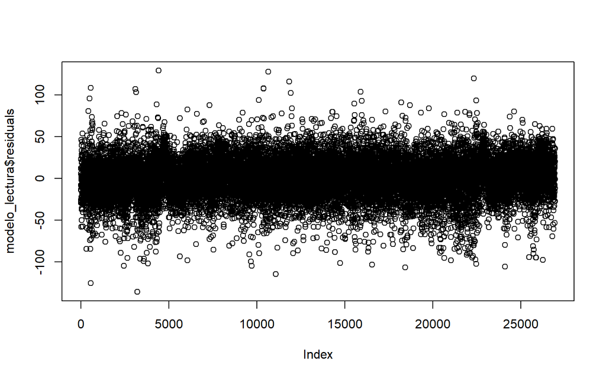

#### Homocedasticidad

El segundo supuesto que debe cumplir una regresión lineal es la Homocedasticidad, es decir que la varianza de los residuos sea constante. Para ello se realiza el test de Breusch Pagan

```
##
##  studentized Breusch-Pagan test
##
## data:  modelo_lectura
## BP = 350.7, df = 4, p-value < 2.2e-16
```

Como podemos ver, se obtiene un *p-value* muy pequeño, por ende se rechaza la hipótesis nula, en otras palabras, se rechaza la existencia de homocedasticidad

#### Normalidad

El tercer supuesto que debe cumplir una regresión lineal es que los residuios del modelo deben distribuir normal. Se realizó un histograma de los residuos y podemos ver que este, se asemeja bastante a la distribución normal que está representada por la curva azul, pero en el punto central de los datos se desvían un poco.

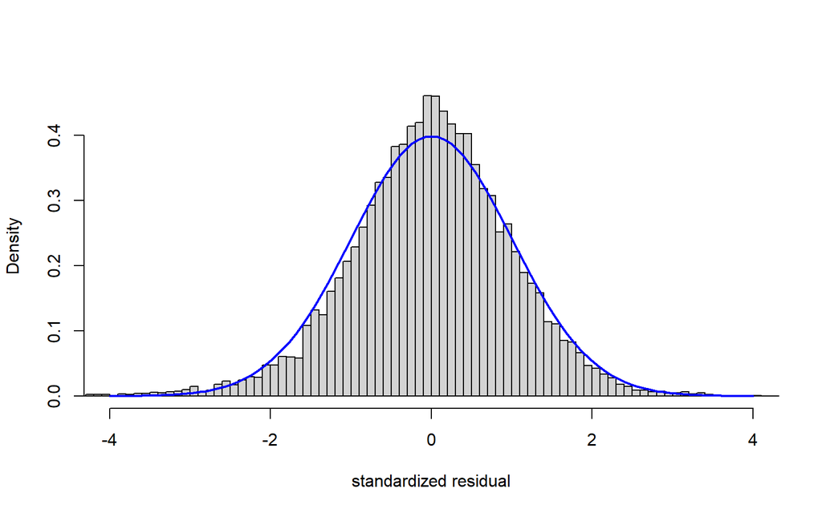

Por otro lado también se realizó un qqplot de los residuos, y podemos notar que en las colas se aleja bastante de la linea roja, que representa los cuantiles teóricos de una distribución normal, por lo tanto no se cumple el supuesto de normalidad

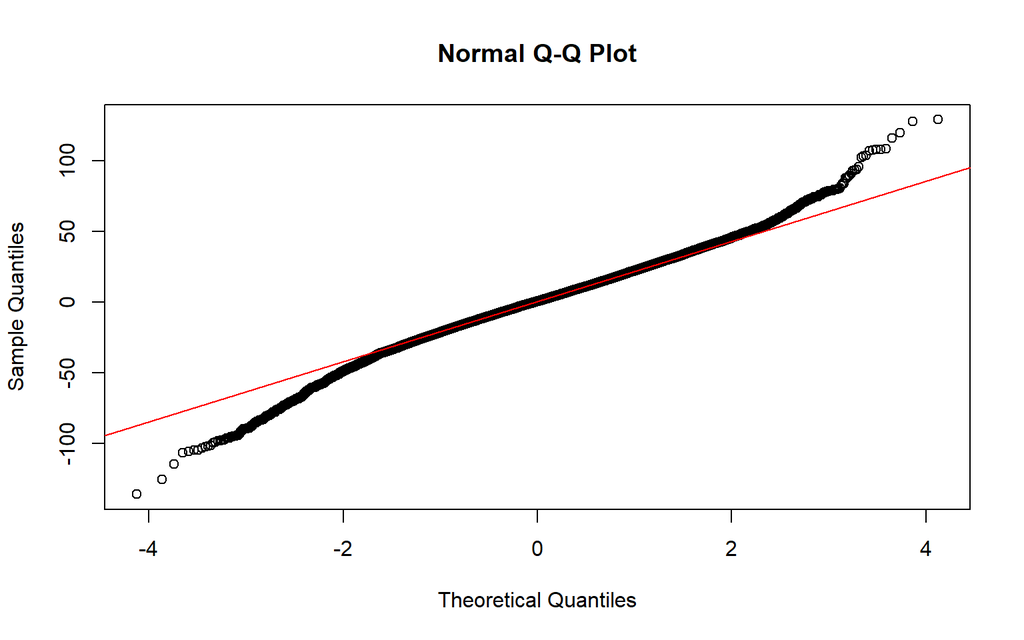

Viendo lo anterior se evaluó la existencia de puntos especificos de los datos que pudiesen estar afectando y dando estos malos resultados, por lo que buscamos los outliers.

#### Outliers

los puntos por sobre y bajo la linea azul son outliers

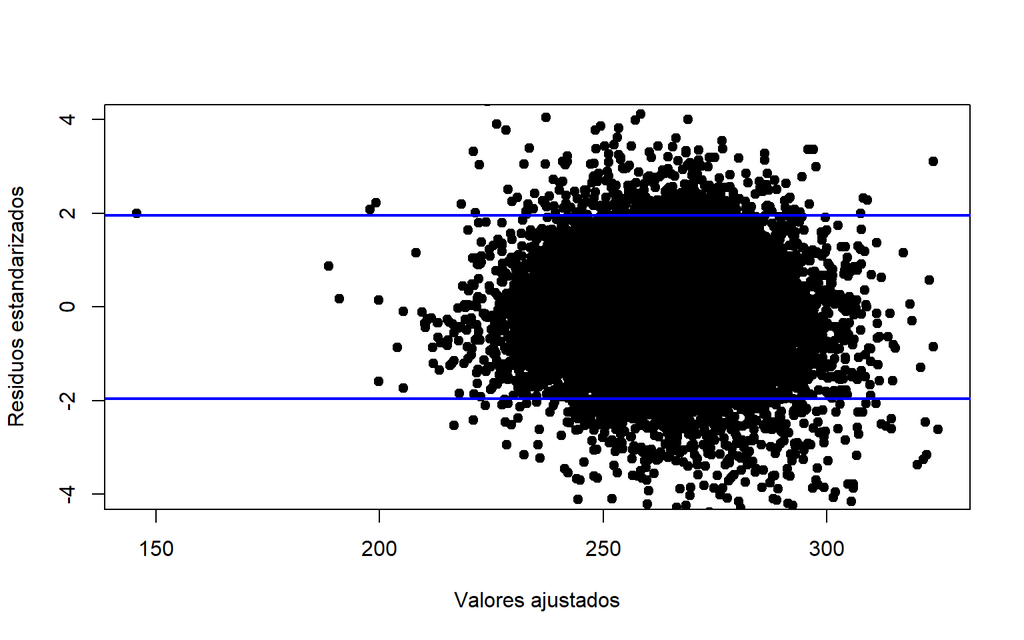

No es una opción la eliminación de outliers pues estos no son valores extremos realizados a partir de muestras mal hechas o algún problema metodológico. Son datos reales y válidos obtenidos de la medición de la prueba SIMCE

El análisis hecho en este segmento para el modelo con la prueba de lectura es análogo al de la prueba de matemática por que son prácticamente iguales las distribuciones de sus datos.

Lamentablemente no fue posible mejorar el ajuste de nuestro modelo.

# Conclusiones

El objetivo de esta investigación fue evaluar cuales eran las variables más importante en cuánto al desempeño de los estudiantes en la prueba SIMCE. Al realizar el análisis descriptivo pudimos ver que las variables estudiadas que mas influían en el aumento o disminución de puntaje en la prueba fueron: el nivel socioeconómico, la convivencia escolar y el autoestima. Es importante mencionar, que estas conclusiones nos permiten tener especial atención en estas variables para futuras investigaciones con bases de datos más grandes, y relacionar las ideas, no obstante en la presente investigación, con sólo el análisis descrpitivo no podemos hacer mas conclusiones a partir de ellas.

Para estudios futuros, sería importante realizar un análisis con técnicas más avanzadas y poder concluir algunas cosas más, de todas formas, lo que se obtuvo en este trabajo nos indica que de todas formas es importante el factor psicosocial en el rendimiento de los alumnos, por lo que serían en general factores importantes a considerar si se quiere mejorar la educación y el rendimiento de los alumnos.

# Referencias

Agencia de la Calidad de la Educación, (sin fecha). Portal de Estudios: Bases de datos. Recuperado de http://informacionestadistica.agenciaeducacion.cl/#/bases